# Sequence composition of HNRNPH binding sites

Mario Keller

Faculty of Biological Sciences, Goethe University Frankfurt

11 November 2022

```r
library(tidyverse)
library(knitr)
library(ggsci)
library(GenomicRanges)
library(ggrepel)
library(Biostrings)
library(BSgenome.Hsapiens.UCSC.hg38)
library(ggseqlogo)
```

```r
myTheme <- theme_bw() +
    theme(axis.text = element_text(size = 14, colour="black"),
          axis.title = element_text(size=16, colour="black"),
          axis.ticks=element_line(color="black"),
          axis.ticks.length=unit(.15, "cm"),
          panel.border=element_rect(color="black", fill = NA),
          panel.background = element_blank(),
          plot.background = element_blank(),
          legend.text = element_text(size=12),
          legend.position = "none")
```

```r
projectDir <- "/Users/mariokeller/projects/HNRNPH_project/Tretow_et_al_2023"

iClipDir <- paste0(projectDir, "/4_iCLIP_analysis")
```

# 1 Background

The sequence composition around binding sites can provide insights into the binding preferences (e.g. motifs or secondary structures) of the RBP of interest. For this purpose,a logo plot was prepared using windows around all binding sites to see if certain nucleotides or stretches of nucleotides are enriched around the binding site centers. In addition, a tetramer analysis was performed between sets of strong and weak binding sites as well as between binding sites located in cooperatively regulated CE events and non-regulated CE events.

# 2 Data

HNRNPH binding sites are loaded from a RDS-File created with *Binding_site_definition.R*.

Regulated and non-regulated CE minigenes are loaded from RDS-Files created with *Create_CE_minigenes.R*.

```r
bindingSites <- readRDS(paste0(iClipDir,
                               "/rds_files/HNRNPH_binding_sites.rds"))

regulatedMiniGenes <- readRDS(paste0(iClipDir, "/rds_files/regulatedMiniGenes.rds"))
nonRegulatedMiniGenes <- readRDS(paste0(iClipDir, "/rds_files/nonregulatedMiniGenes.rds"))
```

Accord to their PureCLIP score, binding sites were labeled as “top20%”, “bottom20%” and “others”.

```r
bindingSites$rank <- cut(bindingSites$score,
                         breaks=quantile(bindingSites$score,
                                         probs=c(0, 0.2, 0.8, 1.0)),
                         labels=c("bottom20%", "others", "top20%"),
                         include.lowest = T)
```

The regulated and non-regulated CE events are stored as GRanges objects with 3 ranges (one for each involved exon). For simplicity evens are reduced to the a single range starting at the start of the leftmost exon and ending at the end of the rightmost exon. In addition I filtered them for cooperatively regulated CE events (Coop-Enh and Coop-Rep).

```r
regulatedMiniGenes <- lapply(regulatedMiniGenes, function(gr){
  event_id <- gr$event_id %>% unique
  hillCat <- gr$hillCat %>% unique
  # range() reduces the three ranges into one range
  gr <- range(gr)
  gr$event_id <- event_id
  gr$hillCat <- hillCat
  return(gr)
}) %>% as(., "GRangesList") %>% unlist
regulatedMiniGenes <- regulatedMiniGenes[regulatedMiniGenes$hillCat %in%
                                             c("Coop-Enh", "Coop-Rep")]

nonRegulatedMiniGenes <- lapply(nonRegulatedMiniGenes, function(gr){
  event_id <- gr$event_id %>% unique
  # range() reduces the three ranges into one range
  gr <- range(gr)
  gr$event_id <- event_id
  gr$hillCat <- "nonReg"
  return(gr)
}) %>% as(., "GRangesList") %>% unlist
```

# 3 Logoplot

As a first step a logo plot was prepared using a window of +/-25 nt around the center of all 468,452 binding sites.

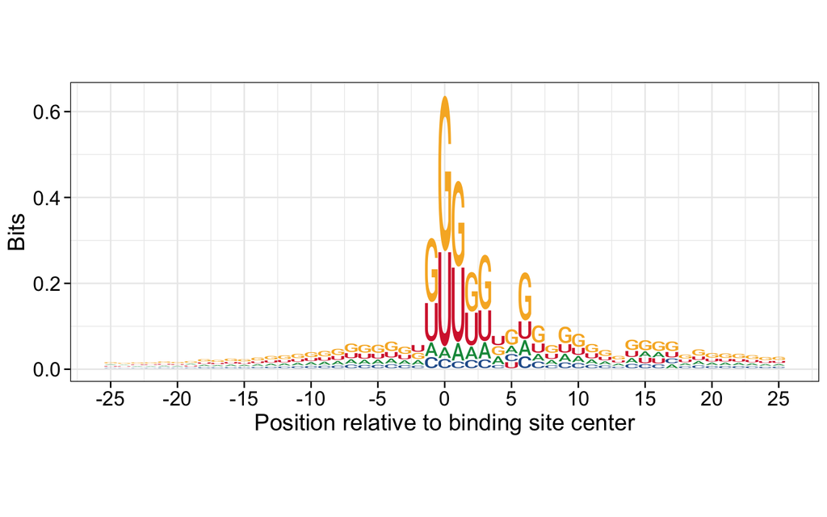

```r
allRSS <-RNAStringSet(getSeq(Hsapiens, bindingSites+23))

ggplot() +
    geom_logo(as.character(allRSS), seq_type="rna", method="bits") +
    scale_x_continuous(breaks = seq(1,51,5), labels = seq(-25, 25, 5)) +
    labs(x="Position relative to binding site center") +
    myTheme +
    theme(aspect.ratio = 1/2.5)
```

Around the center there is a clear enrichment of G-stretches as well as uridines, whereby the latter one reflects the typical iCLIP uridine bias. In addition, further downstream of the binding site center there is also an enrichment of G-stretches.

# 4 Comparative tetramer analysis

## 4.1 Assignment of binding sites to sets

To check for an enrichment of specific tetramers around strong binding sites and binding sites located in cooperatively regulated CE events, these were compared to sets of weak binding sites and binding sites located in non-regulated CE events, respectively.

Comparison1:

- top20%: 20% binding sites with highest PureCLIP score
- bottom20%: 20% binding sites with lowest PureCLIP score

Comparison2:

- coop: Binding sites located in cooperatively regulated CE events
- nonReg: Binding sites located in non-regulated CE events

```r
# Create the four sets
top20 <- bindingSites[bindingSites$rank == "top20%"] + 23
bottom20 <- bindingSites[bindingSites$rank == "bottom20%"] + 23
coop <- subsetByOverlaps(bindingSites, regulatedMiniGenes) + 23
nonReg <- subsetByOverlaps(bindingSites, nonRegulatedMiniGenes) + 23

# Organize them in a list
bindingSiteSets <- list(top20=top20, bottom20=bottom20,
                        coop=coop, nonReg=nonReg)

rm(top20, bottom20, coop, nonReg)
```

Here is the number of binding sites in each set.

```r
data.frame(set=names(bindingSiteSets),
           n = lengths(bindingSiteSets)) %>%
    kable(., "html") %>%
    kableExtra::kable_styling("striped") %>%
    kableExtra::scroll_box(height="300px", width = "94%")
```

|  | set | n |
| --- | --- | --- |
| top20 | top20 | 93691 |
| bottom20 | bottom20 | 93691 |
| coop | coop | 2953 |
| nonReg | nonReg | 11050 |

## 4.2 Tetramer frequencies around the binding sites

First, the RNA sequence of each 51 nt binding site window was determined. Next, all possible tetramers were searched in the binding site windows of each set. Afterwards, the mean frequency of each tetramer in the binding site windows of each set was determined.

```r
# Create for each set a RNAStringSet with the sequence of each window
bindingSiteSetsRSS <- bindingSiteSets %>% lapply(., function(gr){
    return(RNAStringSet(getSeq(Hsapiens, gr)))
})

# Count the occurence of each tetramer in every window and calculate the mean.
#   Combine the results of the four sets in a single data.frame, where
#   rows are tetramers and columns the mean frequency in each set
tetramerDf <- bindingSiteSetsRSS %>% lapply(., function(rss){
    return(oligonucleotideFrequency(rss, 4) %>%
               colMeans())
}) %>%
    do.call("cbind", .) %>%
    as.data.frame() %>%
    tibble::rownames_to_column(var="kmer")

# Add information about G-stretches (GG or GGG)
tetramerDf$Gstretch <- "no"
tetramerDf$Gstretch[grepl("GG", tetramerDf$kmer)] <- "GG"
tetramerDf$Gstretch[grepl("GGG", tetramerDf$kmer)] <- "GGG"
tetramerDf <- tetramerDf %>%
    mutate(Gstretch=factor(Gstretch, levels=c("no", "GG", "GGG"))) %>%
    arrange(Gstretch)
```

## 4.3 Comparative tetramer plots

Mean tetramer frequencies are shown for the top20% and bottom20% set as well as for the coop and nonReg set. Tetramers with G-stretches (GG or GGG) are colored. In addition, a label is added to the 12 most abundant tetramers.

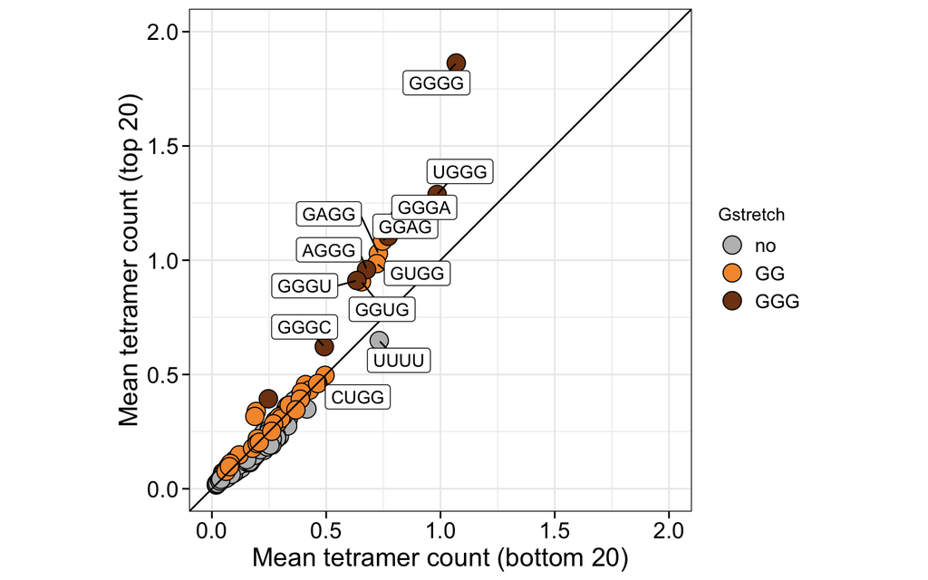

```r
tetramersOfInterest <- tetramerDf %>%
    mutate(avg = dplyr::select(., 2:5) %>% rowMeans()) %>%
    arrange(desc(avg)) %>%
    dplyr::slice(1:12) %>%
    pull(kmer)
tetramerDf$lab <- ""
tetramerDf$lab[match(tetramersOfInterest,
                     tetramerDf$kmer)] <- tetramersOfInterest

ggplot(tetramerDf, aes(x=bottom20, y=top20, fill=Gstretch)) +
    geom_point(shape=21, size=5) +
    geom_abline(slope=1, intercept=0) +
    geom_label_repel(mapping=aes(x=bottom20, y=top20, label=lab), inherit.aes = FALSE, max.overlaps=Inf, min.segment.length=0) +
    scale_fill_manual(values = c("no" = "grey", "GG" = "#F49839", "GGG" = "#7F4112")) +
    coord_cartesian(xlim=c(0, 2), ylim=c(0, 2)) +
    labs(x="Mean tetramer count (bottom 20)", y="Mean tetramer count (top 20)") +
    myTheme +
    theme(aspect.ratio=1/1, legend.position = "right")
```

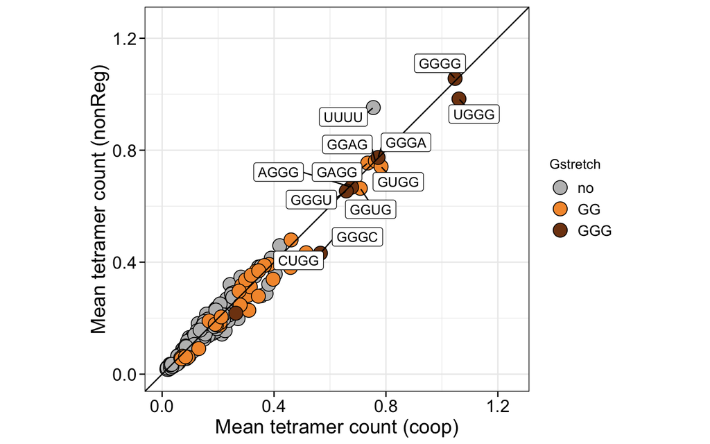

```r
ggplot(tetramerDf, aes(x=coop, y=nonReg, fill=Gstretch)) +
    geom_point(shape=21, size=5) +
    geom_abline(slope=1, intercept=0) +
    geom_label_repel(mapping=aes(x=coop, y=nonReg, label=lab), inherit.aes = FALSE, max.overlaps=Inf, min.segment.length=0) +
    scale_fill_manual(values = c("no" = "grey", "GG" = "#F49839", "GGG" = "#7F4112")) +
    coord_cartesian(xlim=c(0, 1.25), ylim=c(0, 1.25)) +
    labs(x="Mean tetramer count (coop)", y="Mean tetramer count (nonReg)") +
    myTheme +
    theme(aspect.ratio=1/1, legend.position = "right")
```

Among the 20% strongest binding sites there is a clear enrichment of tetramers containing G-triplets with GGGG being the most enriched. In contrast, there are no big differences for G-triplet containing tetramers between binding sites located in cooperatively regulated and non-regulated CE events. The latter observation indicates that the actual position of the binding sites within the events (e.g. in the alternative exon or in the flanking introns) might be different for the two sets.